# *Redes Neuronales*

### Aprendizaje Automatizado del conjunto *MNIST* &

### Aprendizaje Profundo

### [Aprendizaje Profundo y Redes Neuronales](http://neuralnetworksanddeeplearning.com/index.html)

#### Introducción.

El sistema visual humano es una de las maravillas del mundo. Considere la siguiente secuencia de dígitos escritos a mano:

[figure not shown]

La mayoría de las personas reconocen sin esfuerzo esos dígitos como 570139. Esta facilidad engañosa. En cada hemisferio de nuestro cerebro, los humanos tienen una corteza visual primaria, también conocida como V1, que contiene 140 millones de neuronas, con decenas de miles de millones de conexiones entre ellas. Y, sin embargo, la visión humana implica no solo V1, sino toda una serie corticales visuales (V2, V3, V4 y V5) que realizan un procesamiento de imágenes cada vez más complejo.

### [Aprendizaje Profundo y Redes Neuronales](http://neuralnetworksanddeeplearning.com/index.html)

La dificultad del reconocimiento de patrones visuales se hace evidente si intenta escribir un programa de computadora para reconocer dígitos como los anteriores. Lo que parece fácil cuando lo hacemos nosotros mismos de repente se vuelve extremadamente difícil. Las intuiciones simples sobre cómo reconocemos las formas, no son tan simples de expresar algorítmicamente. Cuando tratas de hacer precisas tales reglas, rápidamente te pierdes en una gran cantidad de excepciones y advertencias y casos especiales. Resulta desolador

### [Aprendizaje Profundo y Redes Neuronales](http://neuralnetworksanddeeplearning.com/index.html)

Las redes neuronales abordan el problema de una manera diferente. La idea es tomar un gran número de dígitos escritos a mano, conocidos como ejemplos de capacitación,

[figure not shown]

y luego desarrollar un sistema que pueda aprender de esos ejemplos de entrenamiento. En otras palabras, la red neuronal utiliza los ejemplos para inferir automáticamente reglas para reconocer dígitos escritos a mano. Además, al aumentar el número de ejemplos de capacitación, la red puede aprender más sobre la escritura a mano, y así mejorar su precisión.

### [Aprendizaje Profundo y Redes Neuronales](http://neuralnetworksanddeeplearning.com/index.html)

La dificultad del reconocimiento de patrones visuales se hace evidente si intenta escribir un programa de computadora para reconocer dígitos como los anteriores. Lo que parece fácil cuando lo hacemos nosotros mismos de repente se vuelve extremadamente difícil. Las intuiciones simples sobre cómo reconocemos las formas, no son tan simples de expresar algorítmicamente. Cuando tratas de hacer precisas tales reglas, rápidamente te pierdes en una gran cantidad de excepciones y advertencias y casos especiales. Resulta desolador

Las redes neuronales abordan el problema de una manera diferente. La idea es tomar un gran número de dígitos escritos a mano, conocidos como ejemplos de capacitación,

[figure not shown]

y luego desarrollar un sistema que pueda aprender de esos ejemplos de entrenamiento. En otras palabras, la red neuronal utiliza los ejemplos para inferir automáticamente reglas para reconocer dígitos escritos a mano. Además, al aumentar el número de ejemplos de capacitación, la red puede aprender más sobre la escritura a mano, y así mejorar su precisión.

> *La mayoría de los modelos modernos de aprendizaje profundo se basan en una red neuronal artificial*

### [Aprendizaje Profundo y Redes Neuronales](http://neuralnetworksanddeeplearning.com/index.html)

#### Neuronas Artificiales: El Perceptrón

Las redes de neuronales estan hechas de neuronas y existen varios tipos. Una de ellas es el perceptrón:

[figure not shown]

*Un perceptrón toma varias entradas binarias (tres en este caso), $x_{1}, x_{2}, x_{2}$ y produce una salida binaria única*. Una manera de pensar sobre el perceptrón es que es un dispositivo que toma decisiones al sopesar la evidencia.

### [El Perceptrón](http://neuralnetworksanddeeplearning.com/index.html)

No es muy realista, pero es fácil de entender. Suponga que se acerca el fin de semana, y has oído que habrá un festival de la cerveza en tu ciudad. Te gusta el queso y estás tratando de decidir si ir o no al festival. Puede tomar su decisión sopesando tres factores:

¿El clima esta agradable? ¿Tu novio o novia quiere acompañarte? ¿Está el festival cerca del transporte público? (No tienes auto).

Podemos representar estos tres factores mediante las variables binarias correspondientes $x_{1}, x_{2}, x_{2}$. Por ejemplo, tendríamos $x_{1} = 1$ si el clima es bueno, y $x_{1} = 0$ si el clima es malo. De manera similar, $x_{2} = 1$ si su novio o novia quiere ir, y $x_{2} = 0$ si no. Similarmente de nuevo para $x_{3} = 1$ y transporte público.

Ahora, supongamos que adoras la cerveza, tanto que estás feliz de ir al festival, incluso si a tu novio o novia no le interesa y es difícil llegar al festival. Pero tal vez realmente detestas el mal tiempo, y no hay manera de que vayas al festival si el clima es malo.

### [El Perceptrón](http://neuralnetworksanddeeplearning.com/index.html)

Puede utilizar perceptrones para modelar este tipo de toma de decisiones. En este caso el perceptrón viene dado por

[figure not shown]

Los números(pesos) 6,2,2 se han escogido de manera que reflejen el hecho que el clima es muy importante para usted, mucho más que si su novio o novia se unen a usted o la cercanía del transporte público. Finalmente, suponga que elige un umbral de 5 para el perceptrón. Con estas opciones, el perceptrón implementa el modelo de toma de decisiones deseado, generando 1 cuando el clima es bueno y 0 cuando el clima es malo. No importa el resultado si su novio o novia quiere ir, o si el transporte público está cerca.

Al variar los pesos y el umbral, podemos obtener diferentes modelos de toma de decisiones. Por ejemplo, supongamos que, en cambio, elegimos un umbral de 3. El perceptrón decidirá que deberías ir al festival cuando el tiempo fuera bueno o cuando el festival estaba cerca del transporte público y tu novio o novia estaba dispuesto a unírsele. En otras palabras, sería un modelo diferente de toma de decisiones. Bajar el umbral significa que estás más dispuesto a ir al festival.

### [El Perceptrón](http://neuralnetworksanddeeplearning.com/index.html)

¡Obviamente, el perceptrón no es un modelo completo de toma de decisiones humanas! Pero lo que ilustra el ejemplo es cómo un perceptrón puede sopesar diferentes tipos de evidencia para tomar decisiones. Y debería parecer plausible que una compleja red de perceptrones pueda tomar decisiones bastante sutiles:

[figure not shown]

En esta red, la primera columna de perceptrones (lo que llamaremos la primera *capa* de perceptrones) está tomando tres decisiones muy simples, sopesando la evidencia de entrada. ¿Qué pasa con los perceptrones en la segunda capa? Cada uno de esos perceptrones está tomando una decisión sopesando los resultados del primer nivel de toma de decisiones. De esta manera, los perceptrones en la sucesivos están tomando decisiones a un nivel más complejo y más abstracto que los perceptrones de sus capas anteriores: una red de múltiples capas de perceptrones puede participar en la toma de decisiones sofisticada.

### [El Perceptrón](http://neuralnetworksanddeeplearning.com/index.html)

[figure not shown]

En la red de arriba, los perceptrones parecen tener múltiples salidas. De hecho, todavía son de salida única. Las flechas de salida múltiple son simplemente una forma útil de indicar que la salida de un perceptrón se está utilizando como entrada para varios otros perceptrones. Es menos difícil de manejar que dibujar una sola línea de salida que luego se divide.

*Resulta ser que se pueden idear **algoritmos de aprendizaje** que pueden ajustar automáticamente los pesos de una red de neuronas artificiales. Esta sintonización ocurre en respuesta a estímulos externos, sin la intervención directa de un programador.*

### El problema con los perceptrones

Supongamos que tenemos una red de perceptrones que nos gustaría usar para aprender a resolver un problema, por ejemplo, las entradas a la red podrían ser los datos de píxeles de una imagen escaneada y manuscrita de un dígito. Y nos gustaría que la red aprendiera los pesos para que la salida de la red clasifique correctamente el dígito. Supongamos que hacemos un pequeño cambio en algo de peso en la red. Lo que nos gustaría es que este pequeño cambio en el peso cause solo un pequeño cambio correspondiente en la salida de la red:

[figure not shown]

Así la red 'aprendará' poco a poco. Desafortunadamente, esto no pasa con los percetrones: Cambios pequeños en los pesos no garantizan cambios pequeños en la salida.

### Neurona Sigmoide

Podemos superar este problema introduciendo un nuevo tipo de neurona artificial llamada neurona sigmoide. Las neuronas sigmoides son similares a los perceptrones, pero se modifican de modo que pequeños cambios en sus pesos y sesgos causan solo un pequeño cambio en su producción. Ese es el hecho crucial que permitirá que una red de neuronas sigmoides aprendan. Se presentan las neuronas sigmoideas de la misma manera que describimos los perceptrones:

[figure not shown]

Al igual que un perceptrón, la neurona sigmoide tiene entradas, x1, x2, ... Pero en lugar de ser solo 0 o 1, estas entradas también pueden tomar cualquier valor entre 0 y 1. Entonces, por ejemplo, 0.638 ... es una entrada válida para una neurona sigmoide.

### Neurona Sigmoide

Además, al igual que un perceptrón, la neurona sigmoide tiene pesos para cada entrada, $w_1$, $w_2$. Pero la salida no es 0 o 1. Sino la función:

[figure not shown]

Para ver por qué esta función se parece a un percetrón la graficamos:

```python
import numpy as np
from matplotlib import pyplot as plt

def sigmoid(x):
    return  np.array([1 / (1 + np.exp(-y)) for y in x])


t = np.linspace(-4,4,400)
a = 4*sigmoid(t) - 2

plt.title('Función Sigmoide')
plt.plot(t,a)

plt.show()
```

[output not shown]

Si $\sigma$ hubiera sido de hecho una función escalonada, entonces la neurona sigmoidea sería un perceptrón, ya que la salida sería 1 o 0 dependiendo de si $\mathrm{peso}$ es positivo o negativo:

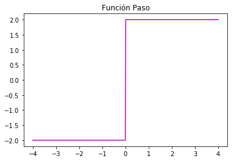

```python
b = 4*np.heaviside(t,.5) - 2
plt.title('Función Paso')
plt
plt.plot(t,b,'m')
plt.show()
```

Al utilizar la función $\sigma$ real, obtenemos, como ya se indicó anteriormente, un perceptrón suavizado. De hecho, es la suavidad de la función $\sigma$ lo que es el hecho crucial, no su forma detallada. La suavidad de $\sigma$ significa que pequeños cambios Δ en los pesos y producirán un pequeño cambio en la salida de la neurona:

$\Delta \mathrm{salida} = \frac{d(\mathrm{salida})}{d (\mathrm{peso})}\Delta (\mathrm{peso})$

Entonces, mientras que las neuronas sigmoideas tienen una gran parte del mismo comportamiento cualitativo que los perceptrones, hacen mucho más fácil descubrir cómo el cambio de los pesos cambiará la salida.

Lo que realmente importa es la forma de $\sigma$, y no su forma exacta. De hecho, se pueden utilizar neuronas donde la salida con otras funciones activación f:

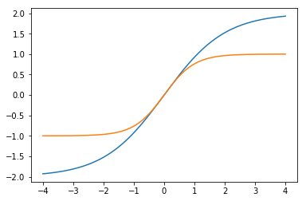

```python
def sigmoid(x):
    return  np.array([1 / (1 + np.exp(-y)) for y in x])

def tanh(x):
    return np.array([np.tanh(y) for y in x])

t = np.linspace(-4,4,400)

a,b = 4*sigmoid(t) - 2, 1*tanh(t) + 0

plt.plot(t,a,t,b)

plt.show();
```

¿Cómo deberíamos interpretar la salida de una neurona sigmoide? Obviamente, una gran diferencia entre los perceptrones y las neuronas sigmoideas es que las neuronas sigmoideas no solo producen la salida 0 o 1. Pueden tener como salida cualquier número real entre 0 y 1, por lo que valores como 0.173 ... y 0.689 ... son salidas legítimas. Esto puede ser útil, por ejemplo, si queremos usar el valor de salida para representar la intensidad promedio de los píxeles en una entrada de imagen a una red neuronal. Pero a veces puede ser una molestia. Supongamos que queremos que la salida de la red indique "la imagen de entrada es un 9" o "la imagen de entrada no es un 9". Obviamente, sería más fácil hacer esto si la salida fuera un 0 o un 1, como en un perceptrón. Pero en la práctica podemos establecer una convención para lidiar con esto, por ejemplo, al decidir interpretar cualquier salida de al menos 0.5 como que indica un "9", y cualquier salida menor a 0.5 indica que "no es un 9". Siempre declararé explícitamente cuando usamos dicha convención, por lo que no debería causar ninguna confusión.

### La arquitectura de las redes neuronales.

Supongamos que tenemos la red:

[figure not shown]

La capa más a la izquierda en esta red se llama la *capa de entrada*, y las neuronas dentro de la capa se llaman *neuronas de entrada*. La capa de la derecha o de salida contiene las neuronas de salida, o, como en este caso, una neurona de *salida única*. La capa intermedia se denomina *capa oculta*, ya que las neuronas en esta capa no son entradas ni salidas.

### La arquitectura de las redes neuronales.

Por ejemplo, la siguiente red de cuatro capas tiene dos capas ocultas:

[figure not shown]

El diseño de las capas de entrada y salida en una red a menudo es sencillo. Por ejemplo, supongamos que estamos tratando de determinar si una imagen escrita a mano representa un "9" o no. Una forma natural de diseñar la red es codificar las intensidades de los píxeles de la imagen en las neuronas de entrada. Si la imagen es de 64 por 64 en escala de grises, tendríamos 4,096 = 64 × 64 neuronas de entrada, con las intensidades escaladas adecuadamente entre 0 y 1. La capa de salida contendrá una sola neurona, con valores de salida inferiores a 0.5 indicando que "la imagen de entrada no es un 9", y valores mayores a 0.5 indicando que "la imagen de entrada es un 9".

Si bien el diseño de las capas de entrada y salida de una red neuronal es a menudo sencillo, puede haber bastante arte en el diseño de las capas ocultas. Hasta ahora, se ha discutido sobre redes neuronales donde la salida de una capa se usa como entrada para la siguiente capa. Estas redes se denominan *redes neuronales de avance*.

### [El conjunto de datos MNIST](http://yann.lecun.com/exdb/mnist/)

Una vez que se tiene un diseño de la red neuronal, ¿cómo puede aprender a reconocer los dígitos? Lo primero que se necesita es un conjunto de datos para aprender, el llamado *conjunto de datos de entrenamiento*.

[El conjunto de datos MNIST](http://yann.lecun.com/exdb/mnist/) contiene decenas de miles de imágenes escaneadas de dígitos escritos a mano, junto con sus clasificaciones correctas. El nombre de MNIST proviene del hecho de que es un subconjunto modificado de dos conjuntos de datos recopilados por NIST, el Instituto Nacional de Estándares y Tecnología de los Estados Unidos.

*La formación de un clasificador con el conjunto de datos MNIST se considera el **hola mundo** del reconocimiento de imágenes.*

Se muestran algunas imágenes típicas de MNIST:

[figure not shown]

Los datos del MNIST vienen en dos partes. La primera parte contiene 60,000 imágenes que se utilizarán como *datos de entrenamiento*. La segunda parte del conjunto de datos MNIST es 10,000 imágenes que se utilizarán como *datos de prueba*. Nuevamente, estas son imágenes de 28 por 28 en escala de grises. Usaremos los datos de prueba para evaluar qué tan bien nuestra red neuronal ha aprendido a reconocer dígitos.

Se usa la notación $x$ para indicar una entrada de entrenamiento. Será conveniente considerar cada entrada de entrenamiento $x$ como un vector de 28 × 28 = 784 dimensiones. Cada entrada en el vector representa el valor de gris para un solo píxel en la imagen. La salida deseada correspondiente es $y = y (x)$, donde $y$ es un vector de 10 dimensiones. Por ejemplo, si una imagen de entrenamiento en particular, $x$, representa un 6, entonces $y (x) = (0,0,0,0,0,0,1,0,0,0)^{\intercal}$ es la salida deseada de la red.

### Función de Costo Cuadrático

Necesitamos un algoritmo que sirva para perfeccionar los pesos de la red, de tal forma que nuestras predicciones sean mejores. Para ello, usamos la [Función de Costo Cuadrático](https://www.codecogs.com/latex/eqneditor.php)

[figure not shown]

Aquí, $w$ denota la colección de todos los pesos en la red, $n$ es el número total de entradas de entrenamiento, $a$ es el vector de salidas de la red cuando $x$ es una entrada, y la suma es sobre todas las entradas de entrenamiento, $X$. Por supuesto, la salida a depende de $x$ y $w$. La notación $\vert\vert v\vert\vert$ solo denota la función de longitud usual para un vector $v$. A $C$ la función de costo cuadrático; a veces también se conoce como *error cuadrático medio (MSE)* , *función de perdida* o *función de objetiva*.

*EL objetivo al entrenar una red neuronal es encontrar pesos que minimicen la función de costo $C$*

Aprovechando que la la función tiene derivadas, se ataca el problema usando *cálculo* para tratar de encontrar el mínimo analíticamente. Se calcular el gradiente de $C$ (o sea sus derivadas) y luego se usa para encontrar lugares donde $C$ es un extremo. Hacerlo directamente se convertie en una pesadilla cuando se tienen muchas más variables: las redes neuronales más grandes tienen funciones de costo que dependen de miles de millones de pesos de una manera extremadamente complicada.

Para hacer esto práctico, es comun usar el *descenso de gradiente estocástico* y el *algoritmo de retropragación* para acelerar el aprendizaje.

### Optimizadores

#### [Descenso de gradiente estocástico](http://neuralnetworksanddeeplearning.com/chap1.html#learning_with_gradient_descent)

La idea es estimar el gradiente de $C$ para una pequeña muestra de insumos de entrenamiento elegidos al azar. Al promediar sobre esta pequeña muestra, se puede obtener rápidamente una buena estimación del gradiente verdadero, y esto ayuda a acelerar el descenso del gradiente y, por lo tanto, el aprendizaje.

#### [Algoritmo de retroprapagación](http://neuralnetworksanddeeplearning.com/chap2.html)

Se calculan los errores comenzando desde la capa final. Puede parecer extraño que estemos retrocediendo por la red. Pero se aprovecha que el retroceso es una consecuencia del hecho de que el costo es una función de las salidas de la red.

### [Funciones de Costo](https://stats.stackexchange.com/questions/154879/a-list-of-cost-functions-used-in-neural-networks-alongside-applications)

Una función de costo es una medida de "qué tan buena" se hizo una red neuronal con respecto a su muestra de capacitación y el resultado esperado. El costo cuadrático no es la unica funcion de costo que se utiliza en redes neuronales. Un ejemplo de otro costo es la [entropía cruzada](http://neuralnetworksanddeeplearning.com/chap3.html#the_cross-entropy_cost_function): $$ C=-\frac{1}{n} \sum_{x}[y \ln a+(1-y) \ln (1-a)] $$

### [Otras Funciones de Activación](https://towardsdatascience.com/activation-functions-neural-networks-1cbd9f8d91d6)

También existen varias de funciones de activación. Una de las funciones más usadas en la actualidad es la [función ReLu](https://medium.com/the-theory-of-everything/understanding-activation-functions-in-neural-networks-9491262884e0).

### [Sobreentrenamiento (Sobreajuste)](http://neuralnetworksanddeeplearning.com/chap3.html#overfitting_and_regularization)

Los modelos con una gran cantidad de parámetros libres pueden describir una variedad asombrosa de fenómenos. Incluso si un modelo de este tipo coincide con los datos disponibles, eso no lo convierte en un buen modelo. Puede significar que hay suficiente libertad en el modelo para que pueda describir casi cualquier conjunto de datos del tamaño dado, sin capturar ninguna visión genuina del fenómeno subyacente. Cuando eso suceda, el modelo funcionará bien para los datos existentes, pero no se generalizará a nuevas situaciones.

En general, una de las mejores maneras de reducir el sobreajuste es aumentar el tamaño de los datos de entrenamiento. Con suficientes datos de entrenamiento, es difícil que incluso una red muy grande se adapte excesivamente. Desafortunadamente, los datos de capacitación pueden ser costosos o difíciles de adquirir, por lo que no siempre es una opción práctica.

### [Regularización](https://www.analyticsvidhya.com/blog/2018/04/fundamentals-deep-learning-regularization-techniques/)

Aumentar la cantidad de datos de entrenamiento es una forma de reducir el sobreajuste. ¿Hay otras maneras en que podamos reducir la medida en que ocurre el sobreajuste? Al conjunto de técnicas que pueden reducir el sobreajuste, incluso cuando tenemos una red fija y datos de entrenamiento fijos, se les denomina métodos o técnias *de regularización* de los datos.

Entre los nombres más populares se encuentran: *L1* , *L2* , *dropout* y *aumento inteligente*.

#### Dropout

Por ejemplo con el dropout se modifica el tamaño de la red.

### Inicializacion de los pesos

Cuando se crea una red neural, se tienen que elegir las ponderaciones y sesgos iniciales. Tambien hay técnicas para eligir pesos iniciales.

### [Rendimiento del modelo (Métricas)](https://stackoverflow.com/questions/48280873/what-is-the-difference-between-loss-function-and-metric-in-keras)

Una métrica es una función que, dados los valores predichos de la red, proporciona una medida escalar de la adecuación del modelo a los datos que se tienen. Una función de pérdida es una métrica, pero lo contrario no siempre se cumple. *Una métrica es una función que se utiliza para juzgar el rendimiento del modelo.*

### [MNIST con Keras](https://nextjournal.com/gkoehler/digit-recognition-with-keras)

Existe una amplia gama de librerias computacionales para semejante empresa. Aqui se usan las librerias **Tensorflow** y **keras** de **python**.

### [TensorFlow](https://www.tensorflow.org/)

TensorFlow es una plataforma de código abierto para el aprendizaje automático. Cuenta con un ecosistema integral y flexible de herramientas, bibliotecas y recursos de la comunidad que permite a los investigadores impulsar el estado de la técnica en ML y los desarrolladores pueden crear y desplegar fácilmente aplicaciones potenciadas por ML.

### [Keras](https://keras.io/)

Keras es una interfaz de programación de aplicaciones (API) de redes neuronales de alto nivel, escrita en Python y capaz de ejecutarse sobre TensorFlow, CNTK o Theano. Fue desarrollado con un enfoque en permitir la experimentación rápida. Poder pasar de la idea al resultado con el menor retraso posible es clave para hacer una buena investigación.

Importaciones para manejo de matrices y figuras.

```python
# Importaciones para manejo de matrices y figuras.
import numpy as np
import matplotlib
#matplotlib.use('agg')
import matplotlib.pyplot as plt
```

```python
# vamos a mantener el backend de tensorflow en silencio
import os
os.environ['TF_CPP_MIN_LOG_LEVEL']='3'
# for testing on CPU
#os.environ['CUDA_VISIBLE_DEVICES'] = ''
```

```python
# Keras importes para el conjunto de datos y para construir la red neuronal
from keras.datasets import mnist
from keras.models import Sequential, load_model
from keras.layers.core import Dense, Dropout, Activation
from keras.utils import np_utils
```

Cargue el conjunto de datos utilizando la función que divide los datos del MNIST en conjuntos de entrenamiento y de prueba.

```python
(X_train, y_train), (X_test, y_test) = mnist.load_data()
```

Inspeccione algunos ejemplos. El conjunto de datos MNIST contiene solo imágenes en escala de grises. Para conjuntos de datos de imagen más avanzados, se tienen los tres canales de color (RGB).

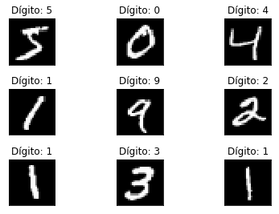

```python
fig = plt.figure()
for i in range(9):
  plt.subplot(3,3,i+1)
  plt.tight_layout()
  plt.imshow(X_train[i], cmap='gray', interpolation='none')
  plt.title("Dígito: {}".format(y_train[i]))
  plt.xticks([])
  plt.yticks([])
fig
plt.show();
```

Para entrenar la red neuronal para clasificar imágenes, primero se ponen los píxeles en un gran vector de entrada: *la capa de entrada*. Así que su longitud debe ser $28\times 28 = 784$. Se grafica la distribución de nuestros valores de píxeles:

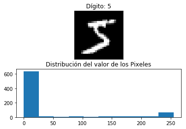

```python
fig = plt.figure()
plt.subplot(2,1,1)
plt.imshow(X_train[0], cmap='gray', interpolation='none')
plt.title("Dígito: {}".format(y_train[0]))
plt.xticks([])
plt.yticks([])
plt.subplot(2,1,2)
plt.hist(X_train[0].reshape(784))
plt.title("Distribución del valor de los Pixeles");
```

Como se esperaba, los valores de los píxeles oscilan entre 0 y 255: la mayoría de fondo (*negro*) está cerca de 0 y los cerca de 255 (*blanco*) representan el dígito.

La normalización de los datos de entrada ayuda a acelerar el entrenamiento. Además, reduce la posibilidad de atascarse en los óptimos locales, ya que estamos usando el descenso de gradiente estocástico para encontrar los pesos óptimos para la red.

Cambie la forma de las entradas a un único vector y normalize los valores del píxel entre 0 y 1.

```python
# imprimamos la forma antes de remodelar y normalizar
print("Forma de X_train", X_train.shape)
print("Forma de Y_train", y_train.shape)
print("Forma de X_test", X_test.shape)
print("Forma de Y_test", y_test.shape)
```

```
Forma de X_train (60000, 28, 28)
Forma de Y_train (60000,)
Forma de X_test (10000, 28, 28)
Forma de Y_test (10000,)
```

```python
# Construyendo el vector de entrada a partir de los 28x28 píxeles.
X_train = X_train.reshape(60000, 784)
X_test = X_test.reshape(10000, 784)
X_train = X_train.astype('float32')
X_test = X_test.astype('float32')


# Normalizando los datos para ayudar con el entrenamiento.
X_train /= 255
X_test /= 255

# imprimir la forma de entrada final listo para el entrenamiento
print("Forma del conjunto de entrenamiento", X_train.shape)
print("Forma del conjunto de prueba", X_test.shape)
```

```
Forma del conjunto de entrenamiento (60000, 784)
Forma del conjunto de prueba (10000, 784)
```

Verificamos que la *verdad*, o sea el conjunto de vectores de salida ($Y$ en la jerga del aprendizaje automático) para capacitar la red tiene sólo enteros de 0 a 9.

```python
print(np.unique(y_train, return_counts=True))
```

```
(array([0, 1, 2, 3, 4, 5, 6, 7, 8, 9], dtype=uint8), array([5923, 6742, 5958, 6131, 5842, 5421, 5918, 6265, 5851, 5949]))
```

```python
# Codificación instantánea utilizando las utilidades de relacionadas de numpy y  keras.
n_classes = 10
print("Forma antes de una 'codificación instantánea': ", y_train.shape)
Y_train = np_utils.to_categorical(y_train, n_classes)
Y_test = np_utils.to_categorical(y_test, n_classes)
print("Forma después de una 'codificación instantánea': ", Y_train.shape)
```

```
Forma antes de una 'codificación instantánea':  (60000,)
Forma después de una 'codificación instantánea':  (60000, 10)
```

## [Construyendo la red](http://alexlenail.me/NN-SVG/index.html)

Utilice Keras para construir la red neuronal.

[figure not shown]

### Construyendo la Red

El vector de píxeles sirve como el conjunto de neuronas entrada. Luego, dos capas ocultas de 512 neuronas (nodos). Para esta arquitectura de red use *el modelo secuencial de Keras*, que representa la clase de modelos lineales en los pesos. Se apilan capas utilizando el método *.add()*.

## Densidad de la Red

Cuando cada neurona de entrada está conectada a cada neurona salida por un peso se dice que la red esta *densamente conectada*(o *totalmente conectada*)

Para la clasificación de múltiples clases, se agreaga otra capa *densamente conectada*(o *totalmente conectada*) para las 10 clases de neuronas de salida diferentes.

```python
# Construyendo una pila lineal de capas con el modelo secuencial.
model = Sequential()
model.add(Dense(512, input_shape=(784,)))
model.add(Activation('relu'))
model.add(Dropout(0.2))

model.add(Dense(512))
model.add(Activation('relu'))
model.add(Dropout(0.2))

model.add(Dense(10))
model.add(Activation('softmax'))
```

Al agregar la primera capa en el Modelo Secuencial, se necesita especificar la forma de entrada para que *Keras* pueda crear las matrices apropiadas. Para todas las capas restantes la forma se deduce automáticamente.

Para introducir no-linealidades en la red y elevarla más allá de las capacidades de un simple *perceptrón*, se han agredado funciones de activación a las capas ocultas. La diferenciación para el entrenamiento a través de la *propagación hacia atrás* se está produce entre bastidores sin tener que implementar los detalles.

También se ha agregado el método de *dropout* para evitar el *sobreajuste*. La fracción de unidades no consideradas se toma como $0.2$

La última capa consta de conexiones para las 10 neuronas de salida. Se incluye la funcion activación de *softmax* (estándar para cuando hay varias salidas).

### Compilación y entrenamiento del modelo

Configure el proceso de aprendizaje utilizando *.compile()*. Aquí se especifica la función de costo(o función objetivo). Para esta configuración, se utiliza la *entropía cruzada*.

En cuanto a la elección del *optimizador*, se elige el optimizador *[Adam](https://arxiv.org/abs/1412.6980v9)* con la configuración predeterminada.

También se elige qué *métricas* se evaluan durante el entrenamiento y las pruebas. Se puede pasar cualquier lista de métricas, incluso construir métricas personalizadas, y hacer que se muestren durante el entrenamiento / prueba.

```python
# compilando el modelo secuencial
model.compile(loss='categorical_crossentropy', metrics=['accuracy'], optimizer='adam')
```

Para controlar el progreso de nuestro entrenamiento, también representamos gráficamente la curva de aprendizaje de nuestro modelo, considerando la pérdida y la precisión. Para trabajar con el modelo entrenado y evaluar su desempeño, estamos guardando el modelo en /data/.

Cada época que pase *keras* informa de los valores del costo(*loss*)y la metrica(*acc*) en los conjuntos de entrenamiento y validacion (para distinguirse, el nombre en las validaciones empieza con el prefeijo *val*)

```python
# Entrenando el modelo y guardando las métricas en la historia.
history = model.fit(X_train, Y_train,
          batch_size=128, epochs=20,
          verbose=2,
          validation_data=(X_test, Y_test))

# guardando el modelo
save_dir = "../data/"
model_name = 'keras_mnist.h5'
model_path = os.path.join(save_dir, model_name)
model.save(model_path)
print('Modelo guardado en  %s ' % model_path)
```

```
Train on 60000 samples, validate on 10000 samples
 - 6s - loss: 0.2517 - acc: 0.9237 - val_loss: 0.1012 - val_acc: 0.9692
 - 6s - loss: 0.1012 - acc: 0.9692 - val_loss: 0.0790 - val_acc: 0.9751
 - 6s - loss: 0.0736 - acc: 0.9761 - val_loss: 0.0681 - val_acc: 0.9789
 - 6s - loss: 0.0544 - acc: 0.9830 - val_loss: 0.0653 - val_acc: 0.9798
 - 6s - loss: 0.0462 - acc: 0.9853 - val_loss: 0.0722 - val_acc: 0.9784
 - 6s - loss: 0.0390 - acc: 0.9866 - val_loss: 0.0632 - val_acc: 0.9797
 - 6s - loss: 0.0346 - acc: 0.9885 - val_loss: 0.0647 - val_acc: 0.9824
 - 6s - loss: 0.0313 - acc: 0.9889 - val_loss: 0.0702 - val_acc: 0.9808
 - 6s - loss: 0.0272 - acc: 0.9905 - val_loss: 0.0738 - val_acc: 0.9807
 - 7s - loss: 0.0271 - acc: 0.9912 - val_loss: 0.0661 - val_acc: 0.9819
 - 7s - loss: 0.0219 - acc: 0.9923 - val_loss: 0.0750 - val_acc: 0.9802
 - 6s - loss: 0.0223 - acc: 0.9925 - val_loss: 0.0725 - val_acc: 0.9818
 - 7s - loss: 0.0214 - acc: 0.9927 - val_loss: 0.0682 - val_acc: 0.9834
 - 7s - loss: 0.0185 - acc: 0.9939 - val_loss: 0.0685 - val_acc: 0.9845
 - 7s - loss: 0.0183 - acc: 0.9940 - val_loss: 0.0714 - val_acc: 0.9829
 - 6s - loss: 0.0172 - acc: 0.9942 - val_loss: 0.0782 - val_acc: 0.9820
 - 6s - loss: 0.0179 - acc: 0.9940 - val_loss: 0.0772 - val_acc: 0.9837
 - 6s - loss: 0.0196 - acc: 0.9934 - val_loss: 0.0789 - val_acc: 0.9836
 - 6s - loss: 0.0141 - acc: 0.9955 - val_loss: 0.0773 - val_acc: 0.9832
 - 6s - loss: 0.0124 - acc: 0.9960 - val_loss: 0.0813 - val_acc: 0.9831
Modelo guardado en  ../data/keras_mnist.h5
```

Grafique la evolucion de la red en cada una de las *épocas*

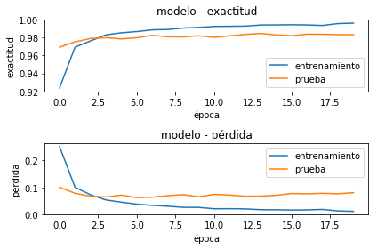

```python
fig = plt.figure()
metrics, plot_number = {'exactitud':'acc', 'pérdida':'loss'}, 1
for metric in metrics:
    keras_name = metrics[metric]
    plt.subplot(2,1,plot_number), plt.plot(history.history[keras_name])
    plt.plot(history.history['val_'+ keras_name])
    plt.title('modelo - ' + metric), plt.ylabel(metric), plt.xlabel('época')
    plt.legend(['entrenamiento', 'prueba'])
    plot_number+=1;
plt.tight_layout()
```

## Evaluación del rendimiento

Es hora de cosechar los frutos del entrenamiento de la red. Vea qué tan bien se desempeña el modelo en el conjunto de pruebas. El método *model.evaluate()* calcula la pérdida y cualquier métrica definida al compilar el modelo. Entonces, en este caso, la precisión se calcula en los 10,000 ejemplos de prueba utilizando los pesos de red dados por el modelo almacenado

```python
mnist_model = load_model("../data/keras_mnist.h5")
loss_and_metrics = mnist_model.evaluate(X_test, Y_test, verbose=2)

print("Prueba-Costo", loss_and_metrics[0])
print("Prueba-Exactitud", loss_and_metrics[1])
```

```
Prueba-Costo 0.08127471554288476
Prueba-Exactitud 0.9831
```

¡Esta precisión se ve muy bien!

```python
# carga el modelo y crear predicciones en el conjunto de prueba
mnist_model = load_model('../data/keras_mnist.h5')
predicted_classes = mnist_model.predict_classes(X_test)

# vea que predijimos correctamente y que no
correct_indices = np.nonzero(predicted_classes == y_test)[0]
incorrect_indices = np.nonzero(predicted_classes != y_test)[0]
print()
print(len(correct_indices),"clasificados correctamente")
print(len(incorrect_indices),"clasificados incorrectamente")
```

```
9831 clasificados correctamente
169 clasificados incorrectamente
```

Vea ejemplos clasificados correctamente e incorrectamente: 9 ejemplos cada uno.

```python
def grafica_predicciones(indices):

    for i, tipo in enumerate(indices):
        plt.subplot(6,3,i+1);
        plt.imshow(X_test[tipo].reshape(28,28), cmap='gray', interpolation='none')
        plt.title(
          "Predicho: {}, Verdad: {}".format(predicted_classes[tipo],
                                            y_test[tipo]))
        plt.xticks([])
        plt.yticks([])
```

```python
# Adapte el tamaño de la figura para acomodar 18 subparcelas.
plt.rcParams['figure.figsize'] = (8,12)
```

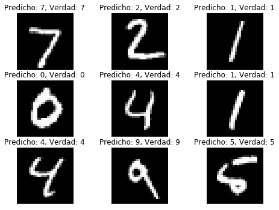

```python
# grafica  9 predicciones correctas
grafica_predicciones(correct_indices[:9])
```

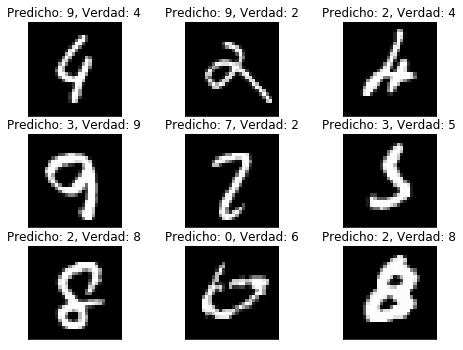

```python
  # grafica 9 predicciones incorrectas
grafica_predicciones(incorrect_indices[:9])
```